# PredictionAssignment

ACrst

24 April 2019

Synopsis: Using devices such as Jawbone Up, Nike FuelBand, and Fitbit it is now possible to collect a large amount of data about personal activity relatively inexpensively. These type of devices are part of the quantified self movement – a group of enthusiasts who take measurements about themselves regularly to improve their health, to find patterns in their behavior, or because they are tech geeks. One thing that people regularly do is quantify how much of a particular activity they do, but they rarely quantify how well they do it. In this project, your goal will be to use data from accelerometers on the belt, forearm, arm, and dumbell of 6 participants. They were asked to perform barbell lifts correctly and incorrectly in 5 different ways.

Data Load

```r
dtraining<-read.csv("https://d396qusza40orc.cloudfront.net/predmachlearn/pml-training.csv")
dtesting<-read.csv("https://d396qusza40orc.cloudfront.net/predmachlearn/pml-testing.csv")
str(dtraining)
```

```
## 'data.frame':    19622 obs. of  160 variables:
##  $ X                       : int  1 2 3 4 5 6 7 8 9 10 ...
##  $ user_name               : Factor w/ 6 levels "adelmo","carlitos",..: 2 2 2 2 2 2 2 2 2 2 ...
##  $ raw_timestamp_part_1    : int  1323084231 1323084231 1323084231 1323084232 1323084232 1323084232 1323084232 1323084232 1323084232 1323084232 ...
##  $ raw_timestamp_part_2    : int  788290 808298 820366 120339 196328 304277 368296 440390 484323 484434 ...
##  $ cvtd_timestamp          : Factor w/ 20 levels "02/12/2011 13:32",..: 9 9 9 9 9 9 9 9 9 9 ...
##  $ new_window              : Factor w/ 2 levels "no","yes": 1 1 1 1 1 1 1 1 1 1 ...
##  $ num_window              : int  11 11 11 12 12 12 12 12 12 12 ...
##  $ roll_belt               : num  1.41 1.41 1.42 1.48 1.48 1.45 1.42 1.42 1.43 1.45 ...
##  $ pitch_belt              : num  8.07 8.07 8.07 8.05 8.07 8.06 8.09 8.13 8.16 8.17 ...
##  $ yaw_belt                : num  -94.4 -94.4 -94.4 -94.4 -94.4 -94.4 -94.4 -94.4 -94.4 -94.4 ...
##  $ total_accel_belt        : int  3 3 3 3 3 3 3 3 3 3 ...
##  $ kurtosis_roll_belt      : Factor w/ 397 levels "","-0.016850",..: 1 1 1 1 1 1 1 1 1 1 ...
##  $ kurtosis_picth_belt     : Factor w/ 317 levels "","-0.021887",..: 1 1 1 1 1 1 1 1 1 1 ...
##  $ kurtosis_yaw_belt       : Factor w/ 2 levels "","#DIV/0!": 1 1 1 1 1 1 1 1 1 1 ...
```

[output cut: 86 more lines]

```r
str(dtesting)
```

```
## 'data.frame':    20 obs. of  160 variables:
##  $ X                       : int  1 2 3 4 5 6 7 8 9 10 ...
##  $ user_name               : Factor w/ 6 levels "adelmo","carlitos",..: 6 5 5 1 4 5 5 5 2 3 ...
##  $ raw_timestamp_part_1    : int  1323095002 1322673067 1322673075 1322832789 1322489635 1322673149 1322673128 1322673076 1323084240 1322837822 ...
##  $ raw_timestamp_part_2    : int  868349 778725 342967 560311 814776 510661 766645 54671 916313 384285 ...
##  $ cvtd_timestamp          : Factor w/ 11 levels "02/12/2011 13:33",..: 5 10 10 1 6 11 11 10 3 2 ...
##  $ new_window              : Factor w/ 1 level "no": 1 1 1 1 1 1 1 1 1 1 ...
##  $ num_window              : int  74 431 439 194 235 504 485 440 323 664 ...
##  $ roll_belt               : num  123 1.02 0.87 125 1.35 -5.92 1.2 0.43 0.93 114 ...
##  $ pitch_belt              : num  27 4.87 1.82 -41.6 3.33 1.59 4.44 4.15 6.72 22.4 ...
##  $ yaw_belt                : num  -4.75 -88.9 -88.5 162 -88.6 -87.7 -87.3 -88.5 -93.7 -13.1 ...
##  $ total_accel_belt        : int  20 4 5 17 3 4 4 4 4 18 ...
##  $ kurtosis_roll_belt      : logi  NA NA NA NA NA NA ...
##  $ kurtosis_picth_belt     : logi  NA NA NA NA NA NA ...
##  $ kurtosis_yaw_belt       : logi  NA NA NA NA NA NA ...
```

[output cut: 86 more lines]

The training data set is made of 19622 observations on 160 columns. As we can see that there are many columns with NAs or blank values, so we will remove them by cleaning the data.

Data clean

```r
ColsToRemove<-which(colSums(is.na(dtraining)|dtraining=="")>0.9*dim(dtraining)[1])
CleanTraining<-dtraining[,-ColsToRemove]
CleanTraining<-CleanTraining[,-c(1:7)]
dim(CleanTraining)
```

```
## [1] 19622    53
```

```r
ColsToRemove<-which(colSums(is.na(dtesting)|dtesting=="")>0.9*dim(dtesting)[1])
CleanTesting<-dtesting[,-ColsToRemove]
CleanTesting<-CleanTesting[,-1]
dim(CleanTesting)
```

```
## [1] 20 59
```

After cleaning the training data set, the cleaned training data set has only 53 columns. We now partition the training data set.

```r
set.seed(12345)
inTrain1<-createDataPartition(CleanTraining$classe,p=0.75,list=FALSE)
Train1<-CleanTraining[inTrain1,]
Test1<-CleanTraining[-inTrain1,]
dim(Train1)
```

```
## [1] 14718    53
```

```r
dim(Test1)
```

```
## [1] 4904   53
```

We will now use three different models: Classification Tree, Random Forests nad Gradient Boosting Method. In order to limit the effects of overfitting and improve the efficiency of the models, we will use cross-validation techniques. For this we will use the k-folds technique.

## Train with Classification Tree

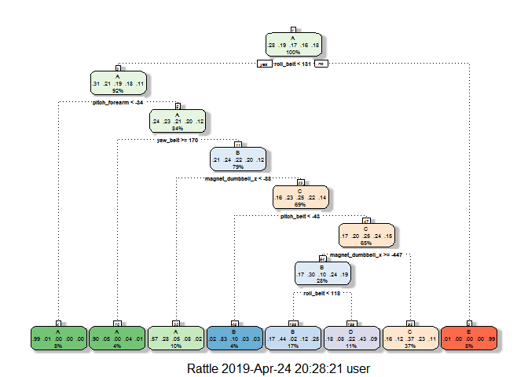

```r
trControl<-trainControl(method="cv",number=5)
modCT<-train(classe~.,data=Train1,method="rpart",trControl=trControl)
fancyRpartPlot(modCT$finalModel)
```

```r
trainPred<-predict(modCT, newdata=Test1)
cMatrix<-confusionMatrix(Test1$classe,trainPred)
cMatrix$overall['Accuracy']
```

```
##  Accuracy
## 0.5415987
```

From this, we observe that the accuracy of this model is about 54.1%. This means that the outcome class will not be predicted very well by the other predictors.

## Train with Random Forests

```r
modRF<-train(classe~.,data=Train1,method="rf",trControl=trControl,verbose=FALSE)
print(modRF)
```

```
## Random Forest
##
## 14718 samples
##    52 predictor
##     5 classes: 'A', 'B', 'C', 'D', 'E'
##
## No pre-processing
## Resampling: Cross-Validated (5 fold)
## Summary of sample sizes: 11776, 11775, 11773, 11774, 11774
## Resampling results across tuning parameters:
##
##   mtry  Accuracy   Kappa
##    2    0.9918466  0.9896855
##   27    0.9923226  0.9902884
##   52    0.9906918  0.9882252
##
## Accuracy was used to select the optimal model using the largest value.
## The final value used for the model was mtry = 27.
```

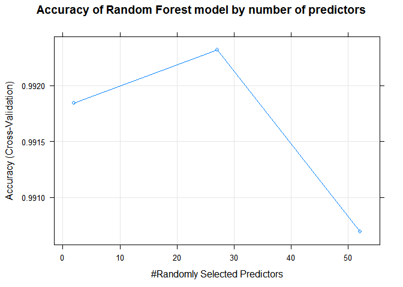

```r
plot(modRF,main="Accuracy of Random Forest model by number of predictors")
```

```r
trainPredRF<-predict(modRF,newdata=Test1)
cMatrixRF<-confusionMatrix(Test1$classe,trainPredRF)
cMatrixRF$table
```

```
##           Reference
## Prediction    A    B    C    D    E
##          A 1394    1    0    0    0
##          B    6  939    4    0    0
##          C    0    2  849    4    0
##          D    0    0   10  794    0
##          E    0    0    2    5  894
```

```r
cMatrixRF$overall['Accuracy']
```

```
##  Accuracy
## 0.9930669
```

```r
modRF$finalModel$classes
```

```
## [1] "A" "B" "C" "D" "E"
```

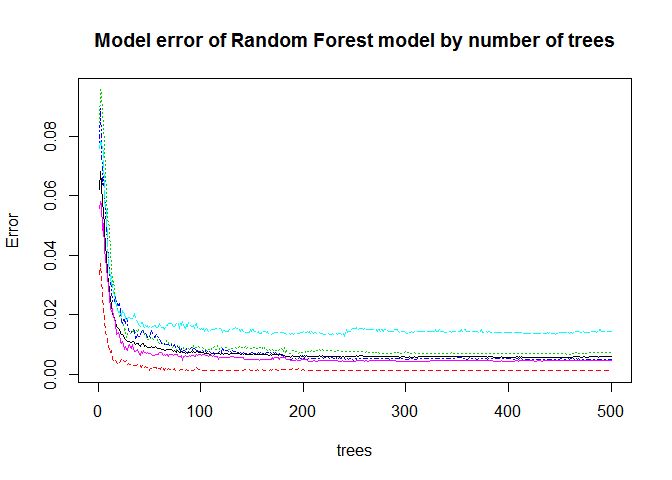

```r
plot(modRF$finalModel,main="Model error of Random Forest model by number of trees")
```

```r
MostImpVars<-varImp(modRF)
MostImpVars
```

```
## rf variable importance
##
##   only 20 most important variables shown (out of 52)
##
##                      Overall
## roll_belt             100.00
## pitch_forearm          57.90
## yaw_belt               56.86
## magnet_dumbbell_z      44.51
## pitch_belt             44.02
## magnet_dumbbell_y      40.55
## roll_forearm           39.56
## accel_dumbbell_y       21.11
## magnet_dumbbell_x      17.90
## roll_dumbbell          17.68
## accel_forearm_x        17.27
## magnet_belt_z          14.44
## accel_dumbbell_z       14.16
## magnet_forearm_z       14.08
## total_accel_dumbbell   13.45
## magnet_belt_y          12.82
## accel_belt_z           12.02
## yaw_arm                11.39
## gyros_belt_z           10.48
## magnet_belt_x          10.18
```

## Train with gradient boosting method

```r
modGBM<-train(classe~.,data=Train1,method="gbm",trControl=trControl,verbose=FALSE)
print(modGBM)
```

```
## Stochastic Gradient Boosting
##
## 14718 samples
##    52 predictor
##     5 classes: 'A', 'B', 'C', 'D', 'E'
##
## No pre-processing
## Resampling: Cross-Validated (5 fold)
## Summary of sample sizes: 11775, 11775, 11774, 11773, 11775
## Resampling results across tuning parameters:
##
##   interaction.depth  n.trees  Accuracy   Kappa
##   1                   50      0.7547203  0.6891712
##   1                  100      0.8194732  0.7714678
##   1                  150      0.8541930  0.8154916
##   2                   50      0.8585420  0.8207615
##   2                  100      0.9064419  0.8816012
##   2                  150      0.9317853  0.9136787
##   3                   50      0.8959101  0.8682235
##   3                  100      0.9406855  0.9249385
##   3                  150      0.9605249  0.9500546
##
## Tuning parameter 'shrinkage' was held constant at a value of 0.1
##
## Tuning parameter 'n.minobsinnode' was held constant at a value of 10
## Accuracy was used to select the optimal model using the largest value.
## The final values used for the model were n.trees = 150,
##  interaction.depth = 3, shrinkage = 0.1 and n.minobsinnode = 10.
```

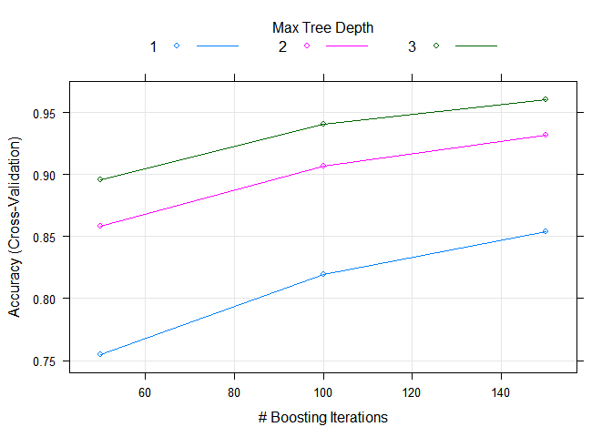

```r
plot(modGBM)
```

```r
trainPredGBM<-predict(modGBM,newdata=Test1)
cMatrixGBM<-confusionMatrix(Test1$classe,trainPredGBM)
cMatrixGBM$table
```

```
##           Reference
## Prediction    A    B    C    D    E
##          A 1378   14    3    0    0
##          B   39  874   34    1    1
##          C    0   20  824   10    1
##          D    0    1   21  776    6
##          E    3    7    8   16  867
```

```r
cMatrix$overall['Accuracy']
```

[output not shown]

Conclusion: This shows us that the random forest model is the best one that we can use out of the three models. We will now use it to predict the values of ‘classe’ in the test data set

```r
FinalTestPred<-predict(modRF,newdata=CleanTesting)
FinalTestPred
```

```
##  [1] B A B A A E D B A A B C B A E E A B B B
## Levels: A B C D E
```